# title: “ELSSP”

### Audiological Characteristics

Hearing loss varies in severity, ranging from slight to profound (@clark1981). More severe hearing loss (less access to spoken language) typically results in more difficulty with spoken language in infancy (@vohr2008), early childhood (@ching2010; @ching2013; @tomblin2015; @sarant2008; @siniger2010) and school-age (@wake2004). Although profound hearing loss is associated with more pronounced spoken language difficulty, even mild to moderate hearing loss is associated with elevated risk of language disorders (@delage2007; @blair1985). Hearing loss also varies in whether it affects one ear or both. Bilateral hearing assists speech perception, sound localization, and loudness perception in quiet and noisy environments (@ching2007). The literature on hearing aids and cochlear implants points to benefits for bilateral auditory input (@sarant2014; @lovett2010; @smulders2016). At school-age, 3–6% of children have unilateral hearing loss (@ross2010). Although children with unilateral hearing loss have one “good ear,” even mild unilateral hearing loss has been tied to higher risk of language delays and educational challenges relative to hearing children (@vila2015; @lieu2013; @lieu2004; @lieu2012, @kiese-himmel2002). That is, just as in the bilateral case, more severe hearing loss leads to greater deficits in language and educational outcomes for children with unilateral hearing loss (@lieu2013;@anne2017). Many DHH children receive hearing aids (HAs) or cochlear implants (CIs) to boost access to the aural world. These devices have been associated with better speech perception and spoken language outcomes (@walker2015; @waltzman1997; @niparko2010). In turn, aided audibility predicts lexical abilities with children in HAs (@stiles2012). For both hearing aids and cochlear implants, earlier fit leads to better spoken language skills, if the amplification is effective. For hearing aids, some studies find that children with milder hearing loss who receive hearing aids earlier have better early language achievement than children who are fit later (@tomblin2015), but this finding does not hold for children with severe to profound hearing loss (@kiese-himmel2002; @watkin2007) (for whom hearing aids are generally ineffective). Analogously, children who are eligible and receive cochlear implants earlier have better speech perception and spoken language outcomes than those implanted later (@dettman2007; @miyamoto2008; @svirsky2004, @yoshinaga-itano2018; @artiere2009), with best outcomes for children receiving implants before their first birthday (@dettman2007).

### Communication

Total Communication (TC) refers to communication that combines speech, gesture, and elements of sign (but not a full sign language, such as American Sign Language), sometimes simultaneously. Clinicians currently employ TC as an alternative or augmentative communication method for children with a wide range of disabilities (@branson2009; @gibbs1991; @mirenda2003).

Compared to total communication, DHH children using an exclusively oral approach have better speech intelligibility (@geers2017; @dillon2004; @geers2002; @hodges1999) and auditory perception (@geers2017; @odonologhue2000). That said, there is some debate as to whether an oral approach facilitates higher spoken language performance, or whether children who demonstrate aptitude for spoken language are steered towards the oral approach rather than TC (@hall2017).

### 1-3-6 Guidelines

Early identification (@yoshinaga-itano2018; @yoshinaga-itano1998; @white1987; @robinshaw1995; @apuzzo1995; @kennedy2006) and timely enrollment in early intervention programs (@vohr2008, @watkin2007; @ching2013; @holzinger2011; @vohr2011) are associated with better language proficiency. Indeed, DHH children who receive prompt diagnosis and early access to services have been found to meet age-appropriate developmental outcomes, including language (@stika2015).

In line with these findings, the American Academy of Pediatricians (AAP) has set an initiative for Early Hearing Detection and Intervention (EHDI). Their EHDI guidelines recommend that DHH children are screened by 1 month old, diagnosed by 3 months old, and enter early intervention services by 6 months old. We refer to this guideline as 1-3-6. Meeting this standard appears to improve spoken language outcomes for children with HL (@yoshinaga-itano2017; @yoshinaga-itano2018) and the benefits appear consistent across a range of demographic characteristics.

At a federal level in the U.S., the Early Hearing Detection and Intervention Act of 2010 (@capps2009) was passed to develop state-wide systems for screening, evaluation, diagnosis, and “appropriate education, audiological, medical interventions for children identified with hearing loss,” but policies for early diagnosis and intervention vary by state. As of 2011, 36 states (including North Carolina, @2000) mandate universal newborn hearing screening (national conference of state legislatures, 2011). All states have some form of early intervention programs that children with hearing loss can access (@nad), but these also vary state-by-state. For instance, half of the states in the US do not consider mild hearing loss an eligibility criterion for early intervention (@holstrum2008).

In evaluating the success of this initiative, the AAP (@ehdi) finds that about 70% of US children who fail their newborn hearing screening test are diagnosed with hearing loss before 3 months old, and that 67% of those diagnosed (46% of those that fail newborn hearing screening) begin early intervention services by 6 months old. These findings suggest that there may be breaks in the chain from screening to diagnosis and from diagnosis to intervention, and the effect may be further delays in language development for children not meeting these guidelines.

## Quantifying vocabulary growth in DHH children

The MacArthur Bates Communicative Development Inventory (CDI, @fenson1994) is a parent-report instrument that gathers information about children’s vocabulary development. The Words and Gestures version of the form (CDI-WG) is normed for 8-18-month-olds, and includes 398 vocabulary items that parents indicate whether their child understands or produces, along with questions about young children’s early communicative milestones. The Words and Sentences version of the form (CDI-WS) is normed for 16-30-month-olds, and includes 680 vocabulary items that parents indicate whether their child produces, along with some questions about grammatical development. The CDI has been normed on a large set of participants across many languages (@anderson2002; @frank2017; @jackson-maldonado2003).

Summary of findings of CDI studies in DHH children

| Study | Population | Gender | 1-3-6 | Laterality | Degree | Amplification | Communication | Comorbidities |
| --- | --- | --- | --- | --- | --- | --- | --- | --- |
| Ching et al., 2013 | 3 year old children receiving services in Australia | Female + | Did not study | Did not study | More severe - | No effect | No effect | Comorbidities - |
| Yoshinaga-Itano et al., 2017 | 8-39 month children with bilateral hearing loss | No effect | 1-3-6 + | Did not study | More severe - | Did not study | Did not study | Comorbidities - |
| Yoshinaga-Itano et al., 2018 | Children with cochlear implants | Did not study | 1-3-6 + | Did not study | Did not study | Earlier CI activation + | Did not study | Did not study |
| De Diego-Lazaro et al., 2018 | Spanish speaking children with bilateral hearing loss | No effect | Earlier intervention + | Did not study | Milder + | More functional hearing + | Did not study | Did not study |
| Vohr et al., 2011 | 18-24 month olds with hearing loss | Did not study | Earlier intervention + | Did not study | Milder + | Did not study | Did not study | NICU stay -; Comorbidities - |

<sup>a</sup> + equals bigger vocab, - equals smaller vocab

## Goals and Predictions

This study aims to 1) characterize the demographic, audiological, and intervention variability in the population of DHH children receiving state services for hearing loss; 2) identify predictors of vocabulary delays; and 3) evaluate the success of early identification and intervention efforts at a state level. We include two subgroups of DHH children traditionally excluded from studies of language development: children with additional disabilities and children with unilateral hearing loss (e.g., @yoshinaga-itano2018).

For the first and third goal above, we did not have specific hypotheses and sought to provide descriptive information about a diverse sample of DHH children receiving state services. For the second, we hypothesized that male gender, more severe degree of hearing loss, bilateral hearing loss, no amplification use, prematurity, and presence of additional disabilities would predict larger spoken vocabulary delay. We did not have strong predictions regarding communication method, language background, or presence of other health issues (e.g., congenital heart malformation).

# Methods

Clinical evaluations were obtained through an ongoing collaboration with the North Carolina Early Language Sensory Support Program (ELSSP), an early intervention program serving children with sensory impairments from birth to 36 months. ELSSP passed along deidentified evaluations to our team after obtaining consent to do so from each family. No eligibility criteria beyond hearing loss and receiving an ELSSP evaluation were imposed, given our goal of characterizing the full range of DHH children with hearing loss in North Carolina.

The clinical evaluations included demographic and audiological information, CDI vocabulary scores, and the results of any clinical assessments administered (e.g., PPVT), all detailed further below. For some children (n=43), multiple evaluations were available from different timepoints. In these cases, only the first evaluation was considered for this study due to concerns regarding within-subjects variance for statistical analysis.

While this collaboration is ongoing, we opted to pause for this analysis upon receiving data from 100 children. Thus, the reported sample below consists of 98 children (55 male/43 female) ages 4.2–36.1666667(M=21.5992189, SD=9.007651). Race and SES information was not available. Families were administered either the WG or WS version of the CDI based on clinician judgement. Children who were too old for WG, but who were not producing many words at the time of assessment, were often given WG (n=37). Families for whom Spanish was the primary language (n = 14) completed the Spanish version of the CDI (@jackson-maldonado2003).

CDI details

| CDI version | Average Age (SD) | Average Comprehension (SD) | Average Production (SD) | % Developmental Delays |
| --- | --- | --- | --- | --- |
| WG (n=73) | 20.07 (8.87) months | 107 (99.9) words | 32 (53.7) words | 17.81% |
| WS (n=25) | 26.05 (8) months | NA | 132 (172.7) words | 4% |

Children in this sample were coded as yes/no for cognitive development concerns (e.g., Down syndrome, global developmental delays; Cornelia de Lange syndrome), yes/no for prematurity (i.e., more than 3 weeks premature), yes/no for health issues (e.g., heart defects, kidney malformations, VACTERL association), and yes/no for vision loss (not corrected to normal by surgery or glasses)

```
FALSE [1] 2
```

Additional Diagnoses (n=37)

| Condition | Specific Condition | n |
| --- | --- | --- |
| Premature |  | 17 |
|  | Extremely Premature | 10 |
|  | NICU stay | 16 |
| Health Issues |  | 34 |
|  | Heart | 10 |
|  | Lung | 6 |
|  | Illness | 15 |
|  | Feeding Issues | 14 |
|  | Pregnancy/Birth Complications | 11 |
|  | Musculoskeletal | 10 |
|  | Cleft Lip/Palate | 4 |
|  | Other | 15 |
| Developmental Concerns |  | 16 |
|  | Down Syndrome | 5 |
|  | Chromosomal Issues | 3 |
|  | Neural Tube Defects | 3 |
|  | Other | 15 |
| Vision Loss |  | 5 |
|  | Retinopathy of Prematurity | 2 |
|  | Nearsightedness | 2 |
|  | Farsightedness | 2 |
|  | Cortical Visual Impairment | 2 |

<sup>a</sup> N.B. ns do not sum to total because many participants had multiple diagnoses

Degree of hearing loss was most often reported with a written description (e.g., “mild sloping to moderate” or “profound high frequency loss”). We created 3 variables: hearing loss in the better ear, hearing loss in the worse ear, and average hearing loss (average of better and worse ear). Using the ASHA hearing loss guidelines, each of these was coded with a dB HL value corresponding with the median dB HL for the level of hearing loss (e.g., moderate hearing loss was coded as 48dB HL), and sloping hearing loss was coded as the average of the levels (e.g. mild to moderate was coded as 40.5 dB HL). Participants were also coded for unilateral or bilateral hearing loss; presence or absence of Auditory Neuropathy Spectrum Disorder; sensorineural, conditive, or mixed hearing loss. Amplification was recorded as the device the child used at the time of assessment–either hearing aid, cochlear implant, or none.

Audiological Characteristics of the Sample for Unilateral / Bilateral Hearing Loss

|  | n | Average HL (better ear) | Average HL (worse ear) | Average Age at Amplification |
| --- | --- | --- | --- | --- |
| Hearing Aid (n=53) | 11 / 42 | 3.89 / 48.49 dB | 58.54 / 56.09 dB | 9.73 / 8.79 months |
| Cochlear Implant (n=17) | 0 / 17 | NA / 85.6 dB | NA / 89.79 dB | NA / 14.12 months |
| No Amplification (n=26) | 14 / 12 | 2.5 / 49.67 dB | 73.9 / 53.65 dB | NA |
| Total (n=98) | 25 / 71 | 3.11 / 57.84 dB | 67.57 / 63.97 dB | NA |

<sup>a</sup> N.B. Age Amplification for children with CIs represents age at implantation

Communication method was recorded as spoken language, total communication, or cued speech. One participant had a parent fluent in sign language, but the reported communication method in the home was total communication. No child in our sample used sign language. Participants were also coded as monolingual or multilingual based on whether families reported using more than one language at home. Total communication was not counted as multilingualism.

Language and communication characteristics of the sample

| Communication Method | English | Spanish | Hindi |
| --- | --- | --- | --- |
| Spoken Language (n=79) | 68 | 10 | 1 |
| Total Communication (n=16) | 13 | 3 | 0 |
| Cued Speech (n=1) | 1 | 0 | 0 |

Meets 1-3-6 table

| Diagnosis by 3 months | 72.04% |
| --- | --- |
| Average Age Diagnosis (SD) | 4.11 (7.34) months |
| Intervention by 6 months | 37.89% |
| Average Age Intervention (SD) | 11.32 (8.75) months |
| Meets 1-3-6 | 36.56% |

Variables table

| Variable | Scale | Range |
| --- | --- | --- |
| Age | Continuous | 4.2-36.16666667 months |
| Age at Amplification | Continuous | 2-31 months |
| Age at Diagnosis | Continuous | 0-30 months |
| Age at Implantation | Continuous | 7-32 months |
| Age at Intervention | Continuous | 1-33 months |
| Amplification | Categorical | Hearing Aid / Cochlear Implant / None |
| Communication | Categorical | Spoken / Total Communication / Cued Speech |
| Degree Hearing Loss (worse ear) | Continuous | 17.75-100 dB HL |
| Developmental Delay | Categorical | Yes / No |
| Gender | Categorical | Female / Male |
| Health Issues | Categorical | Yes / No |
| Language in Home | Categorical | English / Other |
| Laterality | Categorical | Unilateral / Bilateral |
| Meets 1-3-6 | Categorical | Yes / No |
| Prematurity | Categorical | Full-term / Premature |
| Services Received Per Month | Continuous | 0-43 services / month |
| Type of Hearing Loss | Categorical | Sensorineural / Conductive / Mixed |
| CDI - Words Produced | Continuous | 0-635 words |

# Results

All analyses were conducted in R. All code is available on Github. In the first section, we explore relationships among child demographic, audiological, and clinical variables. In the second section, we examine the influence of these factors on vocabulary development. In the third section, we describe the implementation of the EHDI 1-3-6 guidelines and predictors of early diagnosis and intervention.

## Part I: Interactions Among Variables

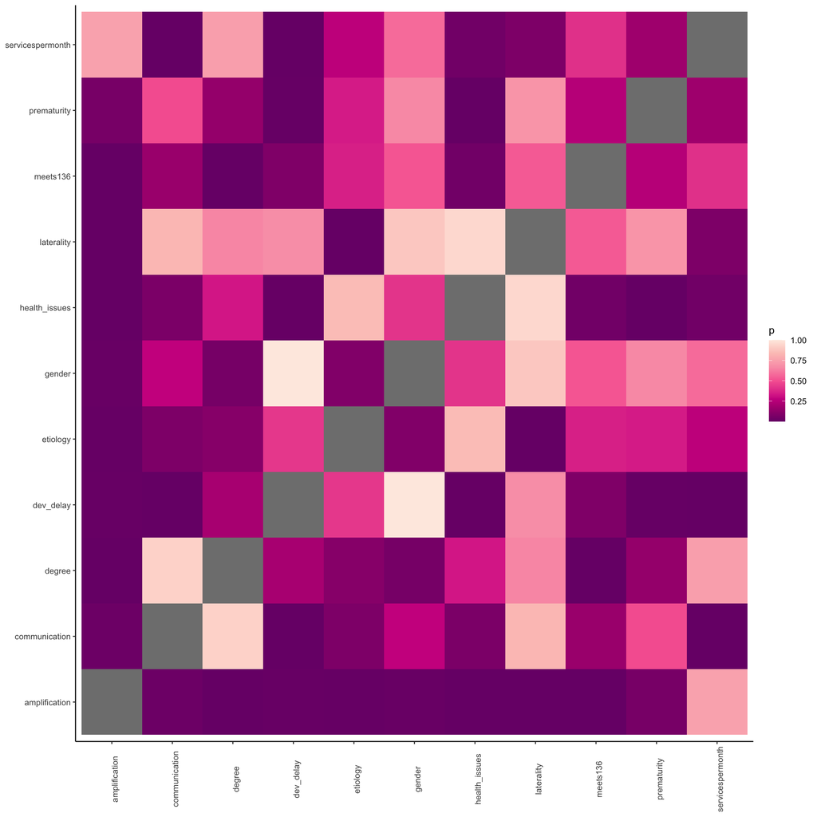

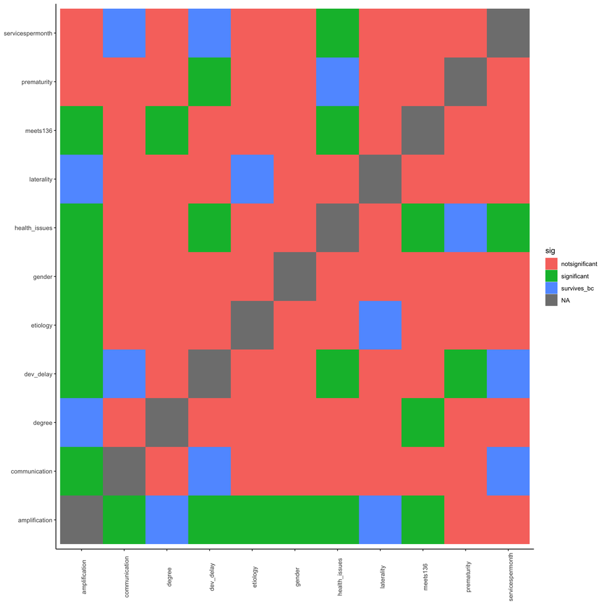

## Part II: Influence on vocabulary

We first constructed a binary logistic growth curve for vocabulary from the 50th percentile data for typically developing children from Wordbank. With this function, each participant’s CDI score yielded a predicted age from the normative data. For each child, we subtracted this predicted age (given the score) from the child’s actual age to give us a measure of delay in months. Descriptively, we found widespread vocabulary delays on both Words and Gestures and Words and Sentences, with the majority of DHH children testing around or below the 25th percentile for hearing children.

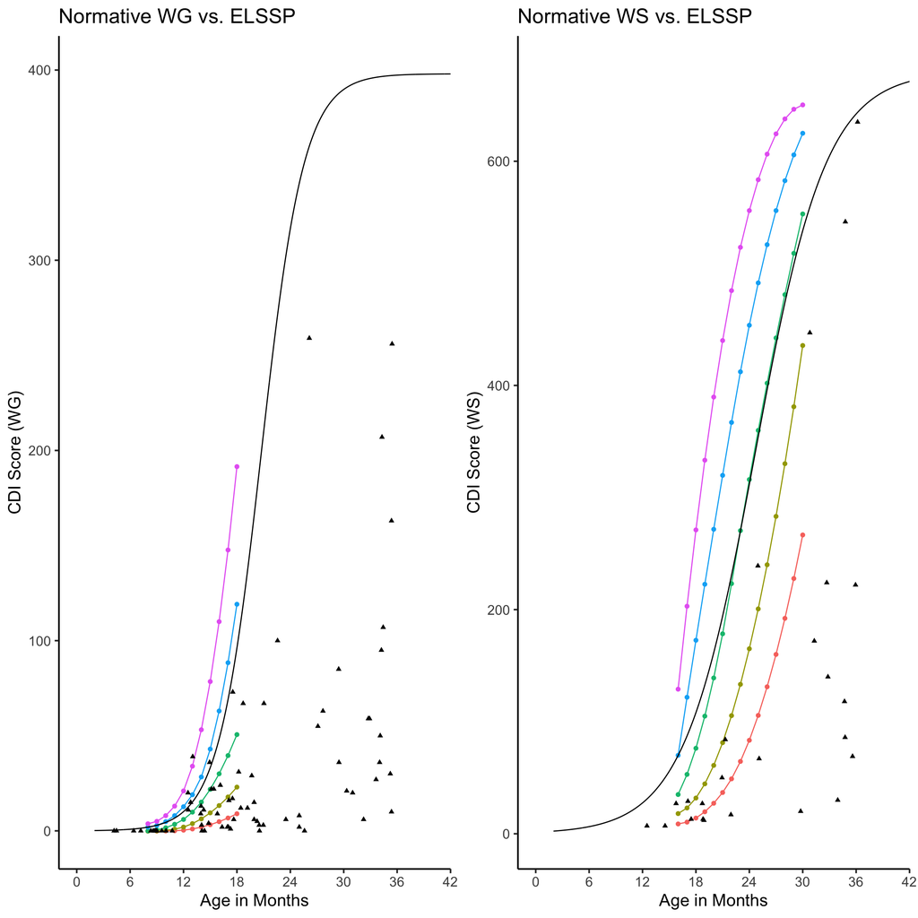

## Part III: Meets136 success

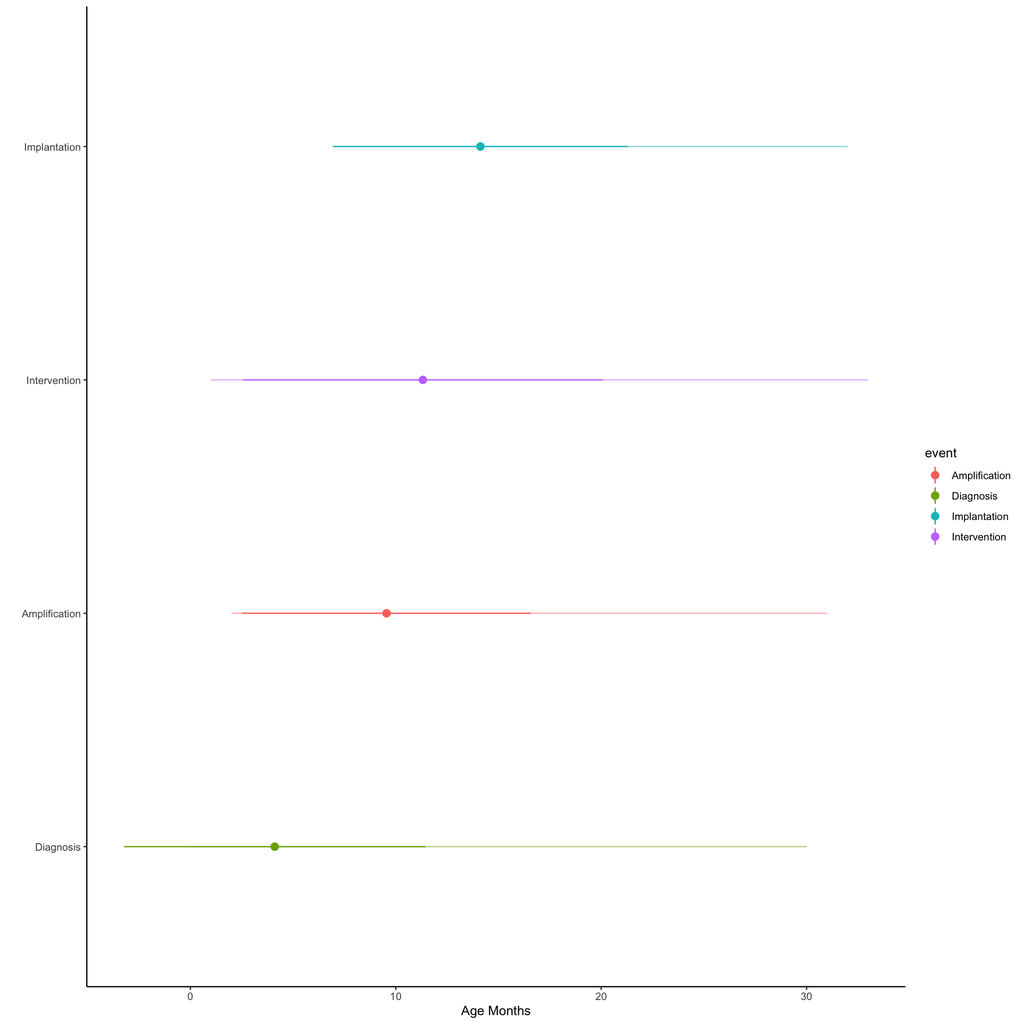

We created linear regression models for age at diagnosis and age at intervention. Models were paired down using stepwise regression by AIC using the stepAIC function (cite MASS package). For age at diagnosis, we included the set of child-specific factors that would be relevant before diagnosis of hearing loss. We began with: Age diagnosis ~ gender + laterality + degree (worse ear) + developmental delay + health issues + prematurity + laterality + language background + etiology The best fit model (R2=0.1887708 , p=8.155682810^{-5} )included health issues (beta weight = 4.1415066, p = 0.0059947) and language background (beta weight = -6.9632948, p = 7.717429610^{-4}). Age diagnosis ~ health issues + language background

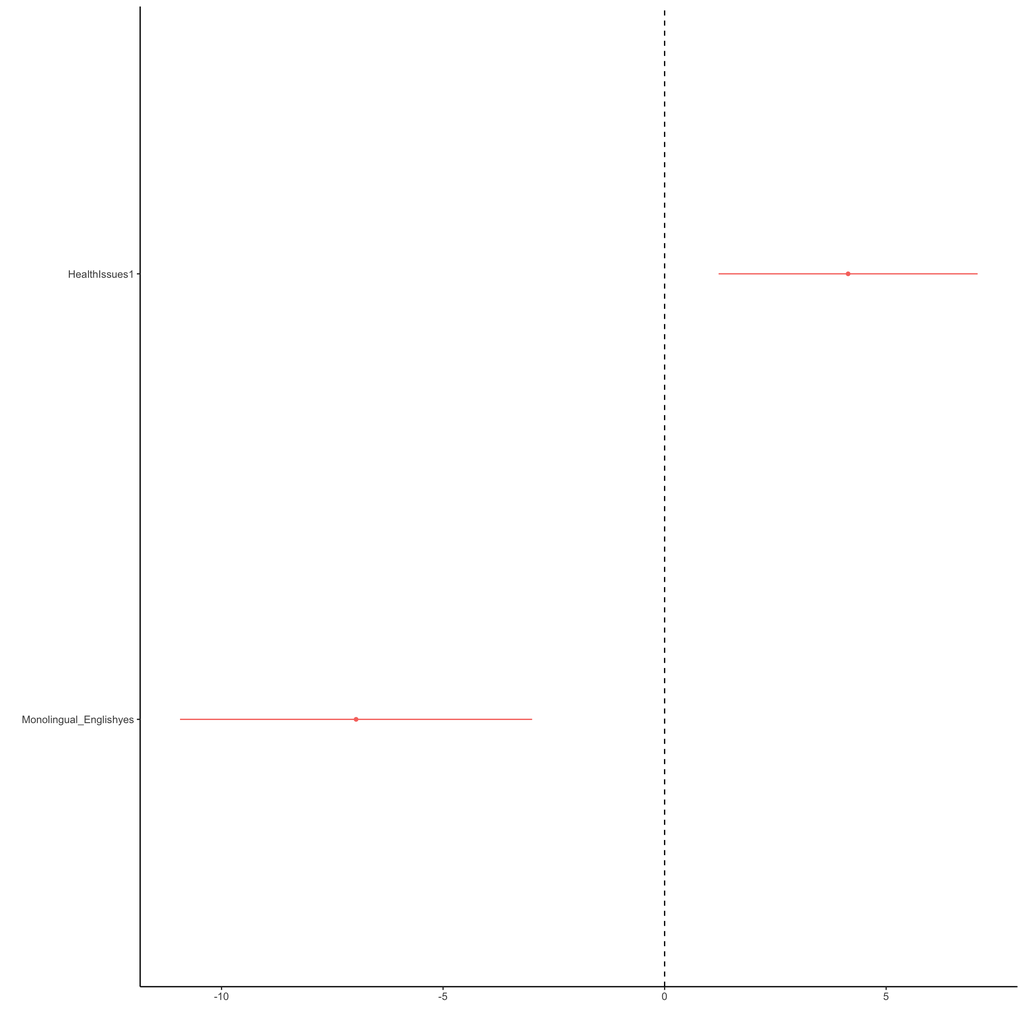

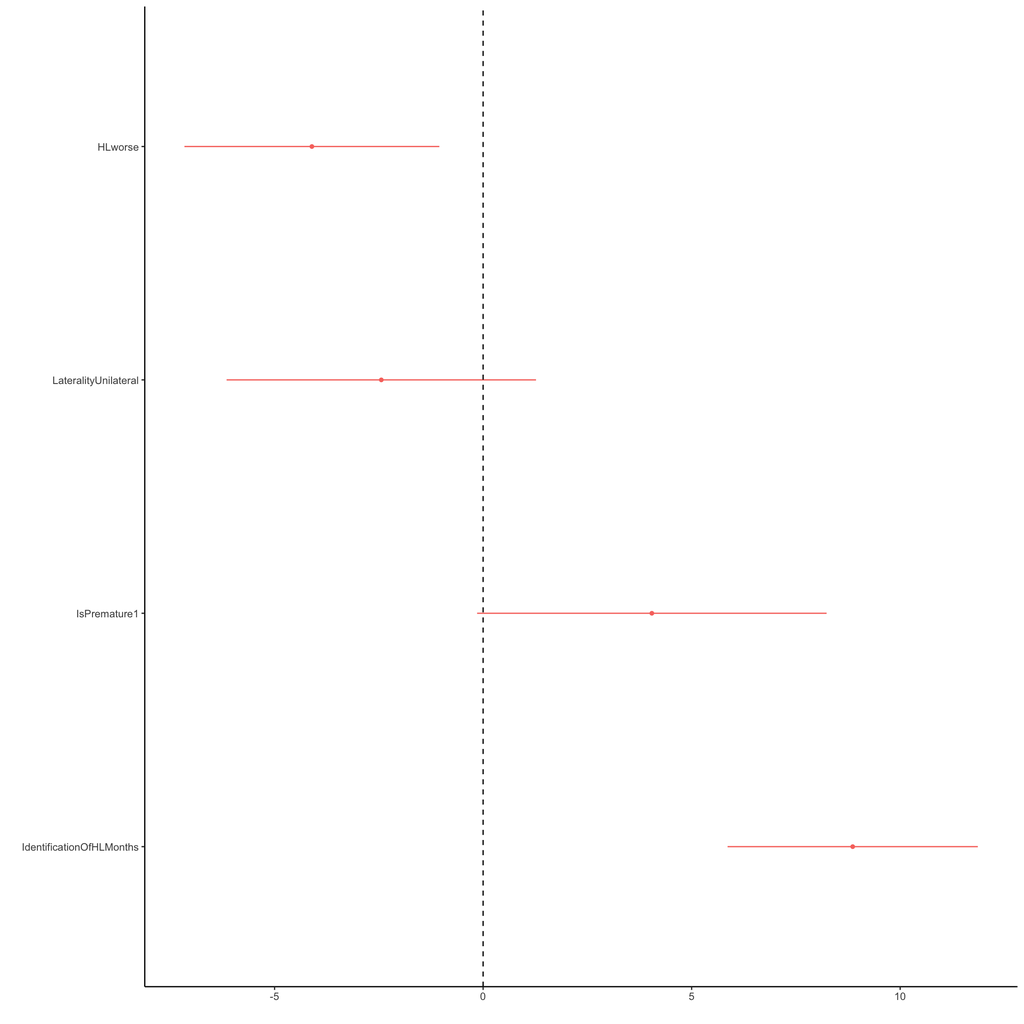

## Discussion

## Conclusion

Footnotes: Despite exciting, increasing, and converging evidence for benefits of early sign language exposure (e.g., @schick2007; @spencer1993; @davidson2014; @magnuson2000; @clark2016; @hrastinski2016), the majority of DHH children will not be raised in a sign language environment. This is particularly true for North Carolina, which does not have a large community of sign language users, relative to states like Maryland or areas like Washington D.C. or Rochester, NY. For this reason, we focus on spoken language development.